# Презентация по лабораторной работе №7

Дисциплина: Архитектура компьютеров и операционные системы

Гусев Степан Андреевич

1032242444@rudn.ru

Российский университет дружбы народов

2026-03-26

# Информация

**Презентация по лабораторной работе №7**

**Автор:** Гусев Степан Андреевич

**Преподаватель:** Кулябов Дмитрий Сергеевич, д.ф.-м.н., профессор кафедры теории вероятностей и кибербезопасности

Российский университет дружбы народов

## Докладчик

- Гусев Степан Андреевич
- Студент программы “Бизнес-информатика”
- Российский университет дружбы народов им. П. Лумумбы
- 1032242444@rudn.ru
- https://github.com/stepagusev

## Цель

Ознакомление с файловой системой Linux, её структурой, именами и содержанием каталогов. Приобретение практических навыков по применению команд для работы с файлами и каталогами, по управлению процессами (и работами), по проверке использования диска и обслуживанию файловой системы.

## Задание

1. Выполнить все примеры, приведённые в первой части описания лабораторной работы
2. Выполнить команды по копированию, созданию и перемещению файлов и каталогов
3. Определить опции команды chmod
4. Изменить права доступа к файлам
5. Прочитать документацию по командам mount, fsck, mkfs, kill и кратко их охарактеризовать с примерами

# Выполнение лабораторной работы

## Выполнение примеров из первой части работы

Создал файл abc1 и скопировал его в файлы april и may.

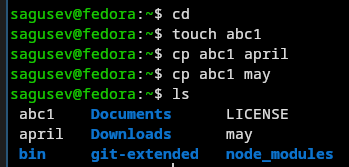

Рисунок 1: Копирование файла

## Выполнение примеров из первой части работы

Создал каталог monthly и скопировал в него файлы april и may.

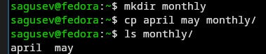

Рисунок 2: Копирование файлов в каталог

## Выполнение примеров из первой части работы

Скопировал файл monthly/may в monthly/june.

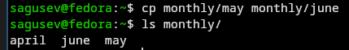

Рисунок 3: Копирование файла в произвольном каталоге

## Выполнение примеров из первой части работы

Создал каталог monthly.00 и скопировал в него каталог monthly.

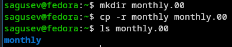

Рисунок 4: Копирование каталога

## Выполнение примеров из первой части работы

Скопировал каталог monthly.00 в /tmp.

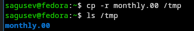

Рисунок 5: Копирование каталога в произвольном каталоге

## Выполнение примеров из первой части работы

Переименовал файл april в july с помощью команды mv.

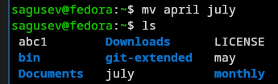

Рисунок 6: Переименование файла

## Выполнение примеров из первой части работы

Переместил файл july в каталог monthly.00 с помощью команды mv.

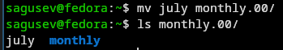

Рисунок 7: Перемещение файла

## Выполнение примеров из первой части работы

Переименовал каталог monthly.00 в monthly.01.

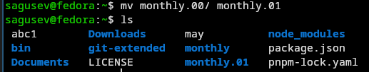

Рисунок 8: Переименование каталога

## Выполнение примеров из первой части работы

Создал каталог reports и переместил в него каталог monthly.01.

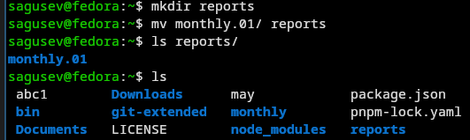

Рисунок 9: Перемещение каталога

## Выполнение примеров из первой части работы

Переименовал каталог reports/monthly.01 в reports/monthly.

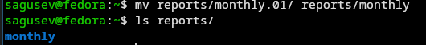

Рисунок 10: Переименование каталога не являющегося текущим

## Выполнение примеров из первой части работы

Создал файл may и задал право выполнения для владельца с помощью команды chmod.

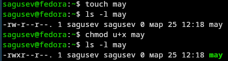

Рисунок 11: Добавление права для файла

## Выполнение примеров из первой части работы

Лишил владельца права выполнения файла may с помощью команды chmod.

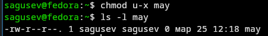

Рисунок 12: Удаление права для файла

## Выполнение примеров из первой части работы

Создал каталог monthly с запретом на чтение для членов группы и всех остальных пользователей.

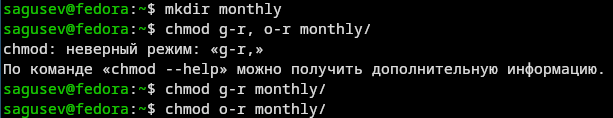

Рисунок 13: Удаление права для каталога

## Выполнение примеров из первой части работы

Создал файл abc1 с правом записи для членов группы.

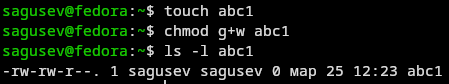

Рисунок 14: Добавление права для файла

## Выполнение примеров из первой части работы

С помощью команды fsck проверил целостность файловой системы.

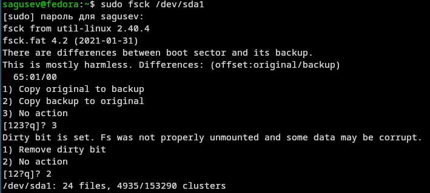

Рисунок 15: Проверка целостности файловой системы

## Выполнение команд по работе с файлами и каталогами

Скопировал файл /usr/include/sys/io.h в ~/equipment.

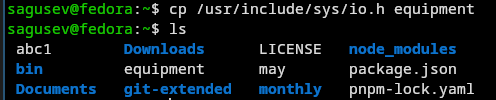

Рисунок 16: Копирование файла

## Выполнение команд по работе с файлами и каталогами

Создал директорию ~/ski.plases.

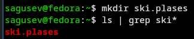

Рисунок 17: Создание каталога

## Выполнение команд по работе с файлами и каталогами

Переместил equipment в ski.plases.

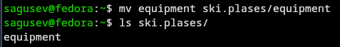

Рисунок 18: Перемещение файла

## Выполнение команд по работе с файлами и каталогами

Переименовал equipment в equiplist.

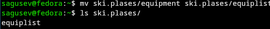

Рисунок 19: Переименование файла

## Выполнение команд по работе с файлами и каталогами

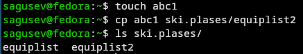

Рисунок 20: Создание файла и его перемещение

## Выполнение команд по работе с файлами и каталогами

В каталоге ski.plases создал подкаталог equipment.

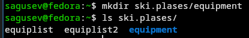

Рисунок 21: Создание подкаталога

## Выполнение команд по работе с файлами и каталогами

Переместил файлы equiplist и equiplist2 в equipment.

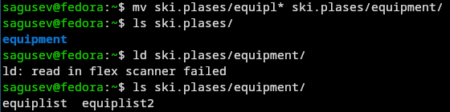

Рисунок 22: Перемещение файлов

## Выполнение команд по работе с файлами и каталогами

Создал каталог newdir и переместил его в ski.plases с названием plans.

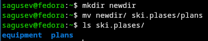

Рисунок 23: Перемещение каталога

## Определение опций команды chmod

С помощью команды chmod и опций g-x, o-x запретил выполнение каталога australia членам группы и всем пользователям.

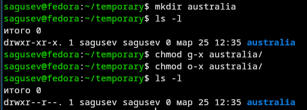

Рисунок 24: Запрещение выполнения

## Определение опций команды chmod

С помощью команды chmod и опций g-r, o-r запретил чтение каталога play членам группы и всем пользователям.

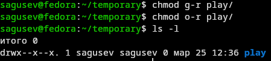

Рисунок 25: Запрещение чтения

## Определение опций команды chmod

С помощью команды chmod и опций u-w, u+x запретил запись и разрешил выполнение файла my_os владельцу.

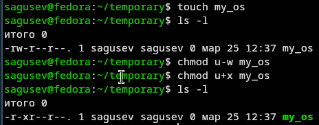

Рисунок 26: Изменение прав владельца

## Определение опций команды chmod

С помощью команды chmod и опций g+w разрешил запись в файл feathers членам группы.

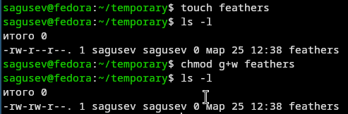

Рисунок 27: Разрешение записи

## Изменение прав доступа к файлам

Просмотрел содержимое файла /etc/passwd.

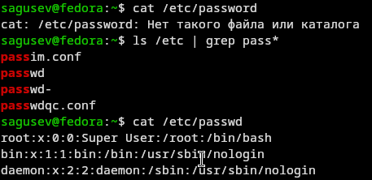

Рисунок 28: Просмотр файла

## Изменение прав доступа к файлам

Скопировал файл ~/feathers в ~/file.old, переместил ~/file.old в ~/play, скопировал ~/play в ~/fun, переместил ~/fun в ~/play под названием games.

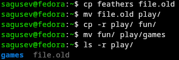

Рисунок 29: Работа с cp и mv

## Изменение прав доступа к файлам

Лишил владельца файла ~/feathers права на чтение, попытался просмотреть содержимое ~/feathers с помощью cat и получил ошибку.

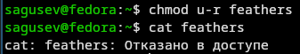

Рисунок 30: Попытка чтения

## Изменение прав доступа к файлам

Лишил владельца каталога ~/play права на выполнение, попытался перейти в ~/play и получил ошибку.

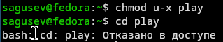

Рисунок 33: Попытка выполнения

## Изменение прав доступа к файлам

Вернул владельцу каталога ~/play право на выполнение.

# Выводы

## Выводы

Я ознакомился с файловой системой Linux, её структурой, именами и содержанием каталогов, приобрёл практические навыки по применению команд для работы с файлами и каталогами, по управлению процессами (и работами), по проверке использования диска и обслуживанию файловой системы.